# DNV Solar Resource Compass — PVPMC 2026 Workshop

**API-centric workflows from resource data to energy yield calculations**

*Thursday 14 May 2026 · PVPMC Workshop, Albuquerque (NM)*

This notebook is your hands-on guide for the Solar Resource Compass (SRC) section of the workshop.  
You will programmatically access three key endpoints:

| Endpoint | Method | What it returns |
| --- | --- | --- |
| `/wcompare` | `compare_weather()` | Multi-source irradiance comparison + TMY hourly dataset |
| `/soil` | `get_soiling()` | Monthly dust & snow soiling loss profiles |
| `/albedo` | `get_albedo()` | Monthly ground albedo with snow-cover days |

**API documentation:** https://api.src.dnv.com/

### Before you start

1. You should have received your `SRC_API_KEY` ahead of the workshop.
2. Set it as an environment variable (`SRC_API_KEY=your-key`) **or** paste it directly in the Setup cell below.
3. Run each cell in order — the cells build on each other.

## 1. Setup & Configuration

```python
import os
import pandas as pd
import matplotlib.pyplot as plt
import matplotlib.ticker as mticker
from solar_resource_compass import SolarResourceCompass

# --- API key ---
# Option A: environment variable (recommended — run: set SRC_API_KEY=your-key  in your terminal)
# Option B: paste your key directly in the string below
API_KEY = os.environ.get("SRC_API_KEY", "YOUR_KEY_HERE")

client = SolarResourceCompass(api_key=API_KEY)
print("Client initialised successfully.")
```

```
Client initialised successfully.
```

## 2. Location Selection

We are meeting in **Albuquerque, New Mexico** — let's use the workshop venue as our example site.  
Feel free to change the coordinates to any location you are interested in.

| Parameter | Value | Notes |
| --- | --- | --- |
| Latitude | 35.10 °N | Hotel Albuquerque |
| Longitude | -106.67 °E |  |
| Elevation | 1510 m | Optional — derived from coords if omitted |

```python
# --- Site coordinates ---
# Try it: swap in your own project site or any location of interest
LATITUDE  = 35.10
LONGITUDE = -106.67
ELEVATION = 1510  # metres above sea level

print(f"Site: {LATITUDE}°N, {LONGITUDE}°E, {ELEVATION} m elevation")
```

```
Site: 35.1°N, -106.67°E, 1510 m elevation
```

## 3. Weather Comparison — `compare_weather()`

The `/wcompare` endpoint pulls irradiance and weather data from **multiple satellite and ground-based datasources** for the site, runs DNV's quality-checking methodology, and returns:

- **`summary`** — which datasource was selected as the TMY and why
- **`metadata`** — per-datasource GHI, DHI, temperature, wind, and quality flags
- **`weather_monthly`** — monthly aggregates per datasource
- **`weather_hourly`** — the selected 8 760-record TMY hourly dataset

This is the first step in any resource assessment workflow.

```python
%%time

weather = client.compare_weather(
    latitude=LATITUDE,
    longitude=LONGITUDE,
    elevation=ELEVATION,
)

print("Summary")
print("-" * 50)
for key, value in weather.summary.items():
    print(f"  {key}: {value}")
```

```
Summary
--------------------------------------------------
  datasets_found: 6
  datasets_enabled: 3
  is_good_coverage: True
  is_microclimate: False
  src_url: https://src.dnv.com/newproject?lat=35.1&lon=-106.67
CPU times: total: 0 ns
Wall time: 12.5 s
```

```python
# Inspect the datasource comparison table
# Each key is a datasource name; each value is a dict of quality metrics
metadata_df = pd.DataFrame(weather.metadata).T

# Columns most relevant to a resource assessment decision
REVIEW_COLUMNS = [
    "provider", "station_name", "dist_km", "elev_delta",
    "ghi_yr_kwh_per_day", "dhi_ghi_frac",
    "ghi_test_pass", "dif_test_pass", "tamb_test_pass", "wspd_test_pass",
    "is_selection",
]
available = [c for c in REVIEW_COLUMNS if c in metadata_df.columns]
metadata_df[available].sort_values("dist_km", na_position="last")
```

|  | provider | station_name | dist_km | elev_delta | ghi_yr_kwh_per_day | dhi_ghi_frac | ghi_test_pass | dif_test_pass | tamb_test_pass | wspd_test_pass | is_selection |
| --- | --- | --- | --- | --- | --- | --- | --- | --- | --- | --- | --- |
| Solargis_Prospect@35.1x-106.67 | Solargis | Site | 0.0 | 1.0 | 5.5994 | 0.23 |  |  |  |  | False |
| MTNM_TMY@35.1x-106.7 | Meteonorm | Site | 0.0 | 4.0 | 5.5514 | 0.26 | True | True | True | True | False |
| Solcast@35.1x-106.7 | Solcast | Site | 0.0 | 0.0 | 5.6345 | 0.24 | True | True | True | False | True |
| NREL_PSM@35.1x-106.7 | NREL | Site | 1.0 | 2.0 | 5.6496 | 0.23 | True | True | True | True | False |
| NREL_TMY2_ALBUQUERQUE | NREL | ALBUQUERQUE | 7.0 | 109.0 | 5.6097 | 0.28 | True | True | True | True | False |
| NREL_TMY3_ALBUQUERQUE INTL ARPT [ISIS] | NREL | ALBUQUERQUE INTL ARPT [ISIS] | 8.0 | 109.0 | 5.4258 | 0.27 | True | True | True | True | False |

## 4. Visualising Weather Data Across Datasources

The chart below compares the annual GHI from every datasource against the DNV reference value, making it easy to see which sources agree and which diverge.

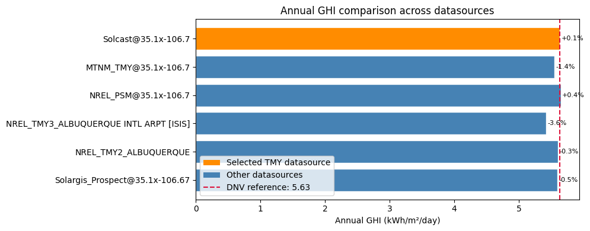

```python
# Build a tidy dataframe of per-datasource GHI for plotting
ghi_df = (
    pd.DataFrame(weather.metadata)
    .T[["ghi_yr_kwh_per_day", "is_selection", "provider"]]
    .dropna(subset=["ghi_yr_kwh_per_day"])
    .rename(columns={"ghi_yr_kwh_per_day": "GHI (kWh/m²/day)"})
)
ghi_df["GHI (kWh/m²/day)"] = pd.to_numeric(ghi_df["GHI (kWh/m²/day)"])

# DNV reference value is the same for every row
dnv_reference = ghi_df["GHI (kWh/m²/day)"].iloc[0]
if "ghi_avg_dnv" in pd.DataFrame(weather.metadata).T.columns:
    dnv_reference = pd.to_numeric(
        pd.DataFrame(weather.metadata).T["ghi_avg_dnv"], errors="coerce"
    ).dropna().iloc[0]

bar_colors = [
    "steelblue" if not row["is_selection"] else "darkorange"
    for _, row in ghi_df.iterrows()
]

fig, ax = plt.subplots(figsize=(10, 4))
bars = ax.barh(ghi_df.index, ghi_df["GHI (kWh/m²/day)"], color=bar_colors, edgecolor="white")
ax.axvline(dnv_reference, color="crimson", linestyle="--", linewidth=1.5, label=f"DNV reference: {dnv_reference:.2f}")
ax.set_xlabel("Annual GHI (kWh/m²/day)")
ax.set_title("Annual GHI comparison across datasources")
ax.legend()

# Label each bar with its % deviation from DNV reference
for bar, (_, row) in zip(bars, ghi_df.iterrows()):
    deviation = (row["GHI (kWh/m²/day)"] - dnv_reference) / dnv_reference * 100
    ax.text(
        bar.get_width() + 0.02,
        bar.get_y() + bar.get_height() / 2,
        f"{deviation:+.1f}%",
        va="center",
        fontsize=8,
    )

# Annotate selected datasource
from matplotlib.patches import Patch
legend_elements = [
    Patch(facecolor="darkorange", label="Selected TMY datasource"),
    Patch(facecolor="steelblue", label="Other datasources"),
]
ax.legend(handles=legend_elements + [ax.lines[0]], loc="lower left")
plt.tight_layout()
plt.show()
```

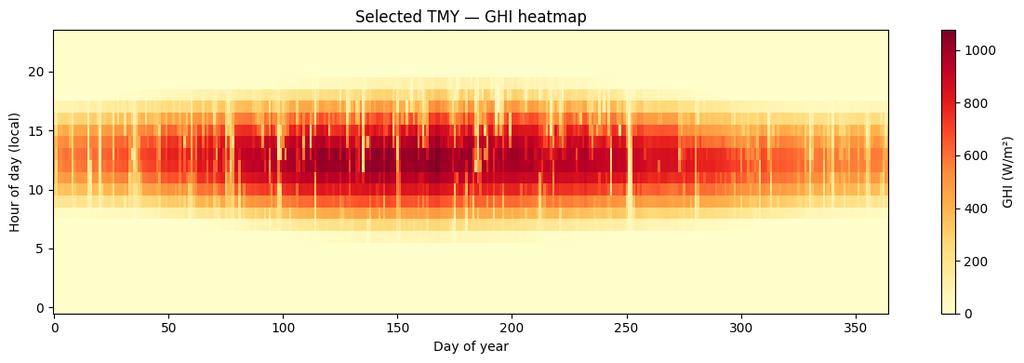

```
TMY dataset: 8760 hourly records
Columns: ['Timestamp', 'GHI', 'DHI', 'Tamb', 'Wspd', 'hour', 'doy']
```

```python
# Plot the selected TMY hourly GHI as a heatmap (hour of day vs day of year)
hourly_df = pd.DataFrame(weather.weather_hourly)
hourly_df["Timestamp"] = pd.to_datetime(hourly_df["Timestamp"])
hourly_df["hour"] = hourly_df["Timestamp"].dt.hour
hourly_df["doy"]  = hourly_df["Timestamp"].dt.dayofyear

pivot = hourly_df.pivot_table(index="hour", columns="doy", values="GHI", aggfunc="mean")

fig, ax = plt.subplots(figsize=(12, 4))
im = ax.imshow(
    pivot,
    aspect="auto",
    origin="lower",
    cmap="YlOrRd",
    interpolation="nearest",
)
plt.colorbar(im, ax=ax, label="GHI (W/m²)")
ax.set_xlabel("Day of year")
ax.set_ylabel("Hour of day (local)")
ax.set_title("Selected TMY — GHI heatmap")
plt.tight_layout()
plt.show()

print(f"\nTMY dataset: {len(hourly_df)} hourly records")
print(f"Columns: {list(hourly_df.columns)}")
```

## 5. Soiling Profile — `get_soiling()`

Soiling reduces PV output by depositing dust and snow on module surfaces.  
The `/soil` endpoint combines:

- **Dust model** — accumulation rate (driven by `dust_soil_type`) counteracted by rainfall wash events
- **Snow model** — based on nearby NOAA ground stations

### Key parameters to explore

| Parameter | Default | Options / range |
| --- | --- | --- |
| `dust_soil_type` | `mild_soil` | `light_soil`, `mild_soil`, `moderate_soil`, `heavy_soil`, `severe_soil` |
| `mounting` | `roof_fixed` | `roof_fixed`, `carport_fixed`, `ground_fixed`, `ground_1axis` |
| `array_tilt` | 10 ° | 0–90 ° |
| `precip_wash_thresh` | 6.25 mm | Minimum rainfall for a clean event |

> **Try it:** change `dust_soil_type` to `"heavy_soil"` or `mounting` to `"ground_fixed"` and re-run to see how the profile changes.

```python
# --- Soiling parameters — experiment with these ---
DUST_SOIL_TYPE      = "mild_soil"    # light_soil | mild_soil | moderate_soil | heavy_soil | severe_soil
MOUNTING            = "ground_1axis" # roof_fixed | carport_fixed | ground_fixed | ground_1axis
ARRAY_TILT          = 30             # degrees (max tracker rotation for 1-axis)
PRECIP_WASH_THRESH  = 6.25           # mm — rainfall needed to reset dust accumulation

soiling = client.get_soiling(
    latitude=LATITUDE,
    longitude=LONGITUDE,
    elevation=ELEVATION,
    dust_soil_type=DUST_SOIL_TYPE,
    mounting=MOUNTING,
    array_tilt=ARRAY_TILT,
    precip_wash_thresh=PRECIP_WASH_THRESH,
)

print("System Attributes")
print("-" * 50)
for key, value in soiling.system_attributes.items():
    print(f"  {key}: {value}")

print("\nNearest snow station used by the model")
print("-" * 50)
for key, value in soiling.snow_metadata.items():
    print(f"  {key}: {value}")
```

```
System Attributes
--------------------------------------------------
  proj_lat: 35.1
  proj_lon: -106.67
  proj_elv: 1510.0
  is_tracker: True
  array_tilt: 30.0
  array_azim: 180
  slant_len: 39.37
  clearance: 36
  string_adj: 0.75
  gcr: 0.3

Nearest snow station used by the model
--------------------------------------------------
  proj_lat: 35.1
  proj_lon: -106.67
  proj_elv: 1510.0
  is_tracker: True
  array_tilt: 30.0
  array_azim: 180
  slant_len: 39.37
  clearance: 36
  string_adj: 0.75
  gcr: 0.3
  Station_rank: 1
  Precip_in_Address: ALBUQUERQUE INTL AP
  Precip_in_Provider: NOAA
  Precip_in_ProductLine: Climate_normals
  Precip_in_ProductVersion: 1991-2020
  Precip_in_DataClass: Standard
  Precip_in_Unit: inch
  Precip_in_dist_km: 8.0
  Precip_in_elev_delta: 108.5
  Precip_in_Latitude: 35.0419
  Precip_in_Longitude: -106.6156
  Precip_in_Elevation: 1618.5
  Snowfall_in_Address: ALBUQUERQUE INTL AP
  Snowfall_in_Provider: NOAA
  Snowfall_in_ProductLine: Climate_normals
```

[output cut: 16 more lines]

```
  Snow_events_Latitude: 35.0419
  Snow_events_Longitude: -106.6156
  Snow_events_Elevation: 1618.5
  RH_Address: ALBUQUERQUE INTL AP
  RH_Provider: NOAA
  RH_ProductLine: Climate_normals
  RH_ProductVersion: 1991-2020
  RH_DataClass: Standard
  RH_Unit: percent
  RH_dist_km: 8.0
  RH_elev_delta: 108.5
  RH_Latitude: 35.0419
  RH_Longitude: -106.6156
  RH_Elevation: 1618.5
  warning:
```

## 6. Visualising Monthly Soiling Losses

```python
soiling_df = pd.DataFrame(soiling.monthly_profiles)

MONTH_ORDER = ["Jan", "Feb", "Mar", "Apr", "May", "Jun",
               "Jul", "Aug", "Sep", "Oct", "Nov", "Dec"]
# Normalize month keys to match MONTH_ORDER format
# Maps potential API response formats (full names, numbers) to standard abbreviations
month_mapping = {
    '1': 'Jan', '2': 'Feb', '3': 'Mar', '4': 'Apr', '5': 'May', '6': 'Jun',
    '7': 'Jul', '8': 'Aug', '9': 'Sep', '10': 'Oct', '11': 'Nov', '12': 'Dec',
}

# Apply mapping to normalize index values
soiling_df.index = soiling_df.index.map(lambda x: month_mapping.get(str(x), str(x)))

# Create categorical index with normalized values
soiling_df.index = pd.CategoricalIndex(soiling_df.index, categories=MONTH_ORDER, ordered=True)
soiling_df = soiling_df.sort_index()

# Show the full table
print(f"Monthly soiling profiles ({DUST_SOIL_TYPE}, {MOUNTING})")
soiling_df
```

```
Monthly soiling profiles (mild_soil, ground_1axis)
```

|  | Snow_events | Snowfall_in | POA | RH | snow_soiling_loss | dust_soil_loss_manwash_0 | dust_soil_loss_manwash_1 | dust_soil_loss_manwash_2 | Precip_in | combined_soil_loss_0 | combined_soil_loss_1 | combined_soil_loss_2 |
| --- | --- | --- | --- | --- | --- | --- | --- | --- | --- | --- | --- | --- |
| Jan | 0.4 | 1.4 | 128.91 | 51.0 | 1.0 | 4.0 | 0.0 | 0.0 | 0.38 | 4.0 | 1.0 | 1.0 |
| Feb | 0.4 | 1.5 | 151.16 | 45.0 | 0.0 | 5.0 | 2.0 | 2.0 | 0.40 | 5.0 | 2.0 | 2.0 |
| Mar | 0.2 | 0.7 | 224.21 | 36.5 | 0.0 | 5.0 | 3.0 | 3.0 | 0.48 | 5.0 | 3.0 | 3.0 |
| Apr | 0.1 | 0.3 | 265.66 | 31.0 | 0.0 | 5.0 | 4.0 | 4.0 | 0.52 | 5.0 | 4.0 | 4.0 |
| May | 0.0 | 0.0 | 310.16 | 30.5 | 0.0 | 6.0 | 5.0 | 5.0 | 0.56 | 6.0 | 5.0 | 5.0 |
| Jun | 0.0 | 0.0 | 315.56 | 28.5 | 0.0 | 5.0 | 5.0 | 5.0 | 0.61 | 5.0 | 5.0 | 5.0 |
| Jul | 0.0 | 0.0 | 302.66 | 41.0 | 0.0 | 2.0 | 2.0 | 2.0 | 1.42 | 2.0 | 2.0 | 2.0 |
| Aug | 0.0 | 0.0 | 275.00 | 44.5 | 0.0 | 1.0 | 1.0 | 1.0 | 1.44 | 1.0 | 1.0 | 1.0 |
| Sep | 0.0 | 0.0 | 236.81 | 42.0 | 0.0 | 1.0 | 1.0 | 1.0 | 1.04 | 1.0 | 1.0 | 1.0 |
| Oct | 0.1 | 0.3 | 190.00 | 42.5 | 0.0 | 1.0 | 1.0 | 1.0 | 0.85 | 1.0 | 1.0 | 1.0 |
| Nov | 0.3 | 0.9 | 137.92 | 45.5 | 0.0 | 2.0 | 2.0 | 0.0 | 0.48 | 2.0 | 2.0 | 0.0 |
| Dec | 0.8 | 2.8 | 125.38 | 53.0 | 1.0 | 3.0 | 3.0 | 2.0 | 0.50 | 3.0 | 3.0 | 2.0 |

```
Found 3 dust scenarios, 3 combined scenarios
```

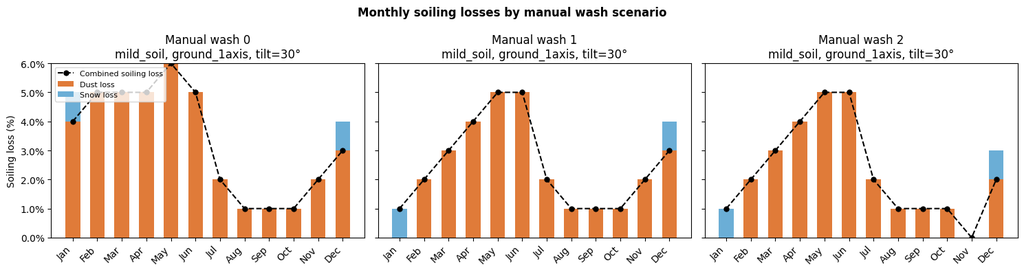

```
Annual average combined soiling loss by scenario:
  Manual wash 0: 3.33%
  Manual wash 1: 2.50%
  Manual wash 2: 2.25%
```

```python
# Identify the actual column names from API response
dust_cols = [c for c in soiling_df.columns if 'dust_soil_loss_manwash' in c]
snow_col = 'snow_soiling_loss' if 'snow_soiling_loss' in soiling_df.columns else None
combined_cols = [c for c in soiling_df.columns if 'combined_soil_loss' in c]

print(f"Found {len(dust_cols)} dust scenarios, {len(combined_cols)} combined scenarios")

# Convert categorical index to strings for x-axis labels
months = [str(m) for m in soiling_df.index]
x = range(len(months))

# Create 3 subplots, one for each manwash scenario
fig, axes = plt.subplots(1, 3, figsize=(15, 4), sharey=True)

scenario_names = ["Manual wash 0", "Manual wash 1", "Manual wash 2"]

for idx, (dust_col, combined_col, ax, scenario) in enumerate(zip(dust_cols, combined_cols, axes, scenario_names)):
    # Build plot columns for this scenario
    plot_cols = []
    if dust_col:
        plot_cols.append(dust_col)
    if snow_col:
        plot_cols.append(snow_col)

    # Use a plain list for bottom to avoid Series alignment issues
    bottom = [0.0] * len(months)
    colors = {dust_col: "#e07b39", snow_col: "#6baed6"}
    labels = {dust_col: "Dust loss", snow_col: "Snow loss"}

    for col in plot_cols:
        values = pd.to_numeric(soiling_df[col], errors="coerce").fillna(0).to_numpy()
        ax.bar(x, values, bottom=bottom, label=labels.get(col, col), color=colors.get(col, "#888888"), width=0.6)
        bottom = [b + v for b, v in zip(bottom, values)]

    # Overlay combined loss as a line
    if combined_col:
        combined = pd.to_numeric(soiling_df[combined_col], errors="coerce").fillna(0)
        ax.plot(x, combined.to_numpy(), "k--o", linewidth=1.5, markersize=5, label="Combined soiling loss")

    ax.set_xticks(list(x))
    ax.set_xticklabels(months, rotation=45, ha='right')
    ax.yaxis.set_major_formatter(mticker.FormatStrFormatter("%.1f%%"))
    ax.set_title(f"{scenario}\n{DUST_SOIL_TYPE}, {MOUNTING}, tilt={ARRAY_TILT}°")

    # Only show legend on first subplot to avoid clutter
    if idx == 0:
        ax.set_ylabel("Soiling loss (%)")
        ax.legend(loc="upper left", fontsize=8)

fig.suptitle("Monthly soiling losses by manual wash scenario", fontsize=12, fontweight='bold')
plt.tight_layout()
plt.show()

# Print annual averages for each scenario
print("\nAnnual average combined soiling loss by scenario:")
for idx, (combined_col, scenario) in enumerate(zip(combined_cols, scenario_names)):
    avg = pd.to_numeric(soiling_df[combined_col], errors="coerce").fillna(0).mean()
    print(f"  {scenario}: {avg:.2f}%")
```

### Exercise: compare dust severity scenarios

Run the cell below to overlay multiple `dust_soil_type` scenarios on one chart — useful for uncertainty banding in an energy yield report.

```python
SCENARIOS = ["light_soil", "mild_soil", "moderate_soil", "heavy_soil"]

# Store results from all scenarios to avoid redundant API calls
scenario_results = {}

print("Fetching soiling data for all dust severity scenarios...")
for scenario in SCENARIOS:
    result = client.get_soiling(
        latitude=LATITUDE,
        longitude=LONGITUDE,
        elevation=ELEVATION,
        dust_soil_type=scenario,
        mounting=MOUNTING,
        array_tilt=ARRAY_TILT,
        precip_wash_thresh=PRECIP_WASH_THRESH,
    )
    scenario_results[scenario] = result
    print(f"  ✓ {scenario}")
```

```
Fetching soiling data for all dust severity scenarios...
  ✓ light_soil
  ✓ mild_soil
  ✓ moderate_soil
  ✓ heavy_soil
```

```
Plotting scenarios...
```

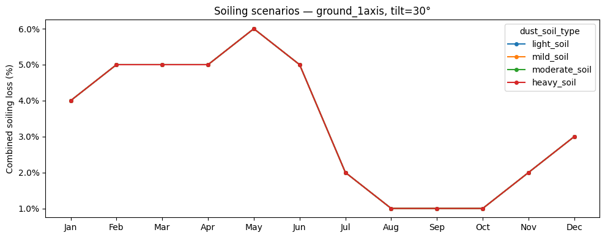

```python
# Plot all scenarios together for comparison
print("\nPlotting scenarios...")
fig, ax = plt.subplots(figsize=(10, 4))

for scenario in SCENARIOS:
    result = scenario_results[scenario]
    monthly = pd.to_numeric(
        pd.Series(result.monthly_profiles['combined_soil_loss_0']), errors="coerce"
    )
    ax.plot(MONTH_ORDER, monthly.to_numpy(), marker="o", markersize=4, label=scenario)

ax.yaxis.set_major_formatter(mticker.FormatStrFormatter("%.1f%%"))
ax.set_ylabel("Combined soiling loss (%)")
ax.set_title(f"Soiling scenarios — {MOUNTING}, tilt={ARRAY_TILT}°")
ax.legend(title="dust_soil_type")
plt.tight_layout()
plt.show()
```

## 7. Albedo Profile — `get_albedo()`

Ground reflectance (albedo) affects bifacial PV yield.  
The `/albedo` endpoint provides:

- **`metadata`** — details of the NOAA station used for snow-cover modelling
- **`monthly_profiles`** — monthly albedo value + number of snow-cover days

Typical bare-ground albedo is ~0.2; snow can push it above 0.6.

```python
albedo = client.get_albedo(
    latitude=LATITUDE,
    longitude=LONGITUDE,
    elevation=ELEVATION,
)

print("Albedo metadata")
print("-" * 50)
for key, value in albedo.metadata.items():
    print(f"  {key}: {value}")

albedo_df = pd.DataFrame(albedo.monthly_profiles)
albedo_df
```

```
Albedo metadata
--------------------------------------------------
  proj_lat: 35.1
  proj_lon: -106.67
  proj_elv: 1510.0
  Snow_days_Address: ALBUQUERQUE INTL AP
  Snow_days_ProductLine: Climate_normals
  Snow_days_ProductVersion: 1991-2020
  Snow_days_Provider: NOAA
  Snow_days_Unit: days
  Snow_days_dist_km: 8.0
  Snow_days_elev_delta: 108.5
```

|  | Snow_days | Albedo |
| --- | --- | --- |
| 1 | 0.8 | 0.2 |
| 2 | 0.6 | 0.2 |
| 3 | 0.2 | 0.2 |
| 4 | 0.0 | 0.2 |
| 5 | 0.0 | 0.2 |
| 6 | 0.0 | 0.2 |
| 7 | 0.0 | 0.2 |
| 8 | 0.0 | 0.2 |
| 9 | 0.0 | 0.2 |
| 10 | 0.1 | 0.2 |
| 11 | 0.3 | 0.2 |
| 12 | 1.1 | 0.2 |

## 8. Visualising Monthly Albedo

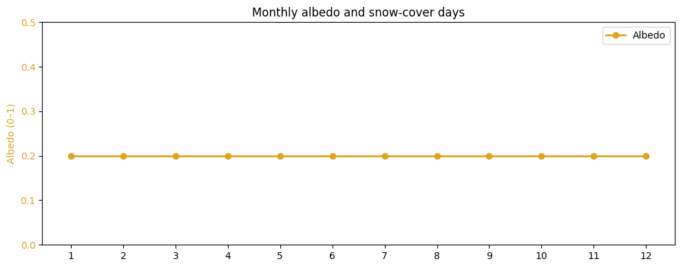

```python
ALBEDO_COL     = "Albedo"
SNOW_DAYS_COL  = "snow_cover_days"

months_albedo = albedo_df.index.tolist()
albedo_values = pd.to_numeric(albedo_df[ALBEDO_COL], errors="coerce")

fig, ax1 = plt.subplots(figsize=(10, 4))

# Albedo line (left axis)
ax1.plot(months_albedo, albedo_values.to_numpy(), "o-", color="goldenrod", linewidth=2, label="Albedo")
ax1.set_ylabel("Albedo (0–1)", color="goldenrod")
ax1.tick_params(axis="y", labelcolor="goldenrod")
ax1.set_ylim(0, max(float(albedo_values.max()) * 1.3, 0.5))

# Snow-cover days bar (right axis) — only when column exists
if SNOW_DAYS_COL in albedo_df.columns:
    snow_days = pd.to_numeric(albedo_df[SNOW_DAYS_COL], errors="coerce").fillna(0)
    ax2 = ax1.twinx()
    ax2.bar(
        months_albedo, snow_days.to_numpy(),
        alpha=0.35, color="steelblue", label="Snow-cover days", width=0.5,
    )
    ax2.set_ylabel("Snow-cover days", color="steelblue")
    ax2.tick_params(axis="y", labelcolor="steelblue")

    # Combined legend
    lines1, labels1 = ax1.get_legend_handles_labels()
    lines2, labels2 = ax2.get_legend_handles_labels()
    ax1.legend(lines1 + lines2, labels1 + labels2, loc="upper right")
else:
    ax1.legend(loc="upper right")

ax1.set_title("Monthly albedo and snow-cover days")
plt.tight_layout()
plt.show()
```

## 9. Resource Summary

The inputs from the analysis can be then used for the PV energy model:

| Inputs for resource assessment | Source |
| --- | --- |
| Hourly Weather Timeseries - selected TMY | `weather.weather_hourly` |
| Soiling | `soiling.monthly_values()` |
| Albedo | `albedo.monthly_values()` |

## Next steps

You now have a complete API-driven resource summary ready for use in an energy yield model.

**What to explore after the workshop:**

- Try a different site — change `LATITUDE`, `LONGITUDE`, `ELEVATION` and re-run all cells
- Adjust `DUST_SOIL_TYPE` for a arid sites (`heavy_soil` or `severe_soil`)
- Feed informed inputs (solar resource, albedo and soiling) into [SolarFarmer](https://www.dnv.com/software/solarfarmer/) for a full energy yield calculation
- Combine multiple API calls in a loop to produce a site portfolio comparison

**API documentation & support:**  
https://api.src.dnv.com/

*Thank you for joining the DNV workshop at PVPMC 2026!*